# Risk Factor Analysis

## Outcome Variable

**Outcome Variable:** whz

## Predictor Variables

**Intervention Variable:** predexfd6

**Adjustment Set:**

- arm
- sex
- W_mage
- meducyrs
- feducyrs
- hhwealth_quart
- hfoodsec
- W_mhtcm
- vagbrth
- W_gagebrth
- W_birthwt
- W_birthlen
- W_nrooms
- W_nchldlt5
- month
- brthmon
- W_parity
- impfloor
- impsan
- safeh20
- delta_W_mage
- delta_meducyrs
- delta_feducyrs
- delta_hhwealth_quart
- delta_hfoodsec
- delta_W_mhtcm
- delta_vagbrth
- delta_W_gagebrth
- delta_W_birthwt
- delta_W_birthlen
- delta_W_nrooms
- delta_W_nchldlt5
- delta_month
- delta_brthmon
- delta_W_parity
- delta_impfloor
- delta_impsan
- delta_safeh20

## Stratifying Variables

The analysis was stratified on these variable(s):

- agecat
- studyid
- country

## Data Summary

| agecat | studyid | country | predexfd6 | n_cell | n |
| --- | --- | --- | --- | --- | --- |
| Birth | ki0047075b-MAL-ED | BANGLADESH | 1 | 114 | 219 |
| Birth | ki0047075b-MAL-ED | BANGLADESH | 0 | 105 | 219 |
| Birth | ki0047075b-MAL-ED | BRAZIL | 1 | 26 | 168 |
| Birth | ki0047075b-MAL-ED | BRAZIL | 0 | 142 | 168 |
| Birth | ki0047075b-MAL-ED | INDIA | 1 | 15 | 187 |
| Birth | ki0047075b-MAL-ED | INDIA | 0 | 172 | 187 |
| Birth | ki0047075b-MAL-ED | NEPAL | 1 | 22 | 165 |
| Birth | ki0047075b-MAL-ED | NEPAL | 0 | 143 | 165 |
| Birth | ki0047075b-MAL-ED | PERU | 1 | 104 | 249 |
| Birth | ki0047075b-MAL-ED | PERU | 0 | 145 | 249 |
| Birth | ki0047075b-MAL-ED | SOUTH AFRICA | 1 | 3 | 209 |
| Birth | ki0047075b-MAL-ED | SOUTH AFRICA | 0 | 206 | 209 |
| Birth | ki0047075b-MAL-ED | TANZANIA, UNITED REPUBLIC OF | 1 | 1 | 115 |
| Birth | ki0047075b-MAL-ED | TANZANIA, UNITED REPUBLIC OF | 0 | 114 | 115 |
| Birth | ki1000108-CMC-V-BCS-2002 | INDIA | 1 | 7 | 7 |
| Birth | ki1000108-CMC-V-BCS-2002 | INDIA | 0 | 0 | 7 |
| Birth | ki1000108-IRC | INDIA | 1 | 0 | 12 |
| Birth | ki1000108-IRC | INDIA | 0 | 12 | 12 |
| Birth | ki1000109-EE | PAKISTAN | 1 | 0 | 1 |
| Birth | ki1000109-EE | PAKISTAN | 0 | 1 | 1 |
| Birth | ki1000304b-SAS-CompFeed | INDIA | 1 | 45 | 47 |
| Birth | ki1000304b-SAS-CompFeed | INDIA | 0 | 2 | 47 |
| Birth | ki1101329-Keneba | GAMBIA | 1 | 451 | 1336 |
| Birth | ki1101329-Keneba | GAMBIA | 0 | 885 | 1336 |
| Birth | kiGH5241-JiVitA-3 | BANGLADESH | 1 | 12395 | 15420 |
| Birth | kiGH5241-JiVitA-3 | BANGLADESH | 0 | 3025 | 15420 |
| Birth | kiGH5241-JiVitA-4 | BANGLADESH | 1 | 521 | 633 |
| Birth | kiGH5241-JiVitA-4 | BANGLADESH | 0 | 112 | 633 |
| 6 months | ki0047075b-MAL-ED | BANGLADESH | 1 | 123 | 235 |
| 6 months | ki0047075b-MAL-ED | BANGLADESH | 0 | 112 | 235 |

[output cut: 64 more lines]

The following strata were considered:

- agecat: 24 months, studyid: ki0047075b-MAL-ED, country: BANGLADESH
- agecat: 24 months, studyid: ki0047075b-MAL-ED, country: BRAZIL
- agecat: 24 months, studyid: ki0047075b-MAL-ED, country: INDIA
- agecat: 24 months, studyid: ki0047075b-MAL-ED, country: NEPAL
- agecat: 24 months, studyid: ki0047075b-MAL-ED, country: PERU
- agecat: 24 months, studyid: ki0047075b-MAL-ED, country: SOUTH AFRICA
- agecat: 24 months, studyid: ki0047075b-MAL-ED, country: TANZANIA, UNITED REPUBLIC OF
- agecat: 24 months, studyid: ki1000108-CMC-V-BCS-2002, country: INDIA
- agecat: 24 months, studyid: ki1000108-IRC, country: INDIA
- agecat: 24 months, studyid: ki1017093b-PROVIDE, country: BANGLADESH
- agecat: 24 months, studyid: ki1101329-Keneba, country: GAMBIA
- agecat: 24 months, studyid: ki1113344-GMS-Nepal, country: NEPAL
- agecat: 24 months, studyid: ki1148112-LCNI-5, country: MALAWI
- agecat: 24 months, studyid: kiGH5241-JiVitA-3, country: BANGLADESH
- agecat: 24 months, studyid: kiGH5241-JiVitA-4, country: BANGLADESH
- agecat: 6 months, studyid: ki0047075b-MAL-ED, country: BANGLADESH
- agecat: 6 months, studyid: ki0047075b-MAL-ED, country: BRAZIL
- agecat: 6 months, studyid: ki0047075b-MAL-ED, country: INDIA
- agecat: 6 months, studyid: ki0047075b-MAL-ED, country: NEPAL
- agecat: 6 months, studyid: ki0047075b-MAL-ED, country: PERU
- agecat: 6 months, studyid: ki0047075b-MAL-ED, country: SOUTH AFRICA
- agecat: 6 months, studyid: ki0047075b-MAL-ED, country: TANZANIA, UNITED REPUBLIC OF
- agecat: 6 months, studyid: ki1000108-CMC-V-BCS-2002, country: INDIA
- agecat: 6 months, studyid: ki1000108-IRC, country: INDIA
- agecat: 6 months, studyid: ki1000109-EE, country: PAKISTAN
- agecat: 6 months, studyid: ki1000304b-SAS-CompFeed, country: INDIA
- agecat: 6 months, studyid: ki1000304b-SAS-FoodSuppl, country: INDIA
- agecat: 6 months, studyid: ki1017093b-PROVIDE, country: BANGLADESH
- agecat: 6 months, studyid: ki1101329-Keneba, country: GAMBIA
- agecat: 6 months, studyid: ki1113344-GMS-Nepal, country: NEPAL
- agecat: 6 months, studyid: ki1148112-LCNI-5, country: MALAWI
- agecat: 6 months, studyid: kiGH5241-JiVitA-3, country: BANGLADESH
- agecat: 6 months, studyid: kiGH5241-JiVitA-4, country: BANGLADESH
- agecat: Birth, studyid: ki0047075b-MAL-ED, country: BANGLADESH
- agecat: Birth, studyid: ki0047075b-MAL-ED, country: BRAZIL
- agecat: Birth, studyid: ki0047075b-MAL-ED, country: INDIA
- agecat: Birth, studyid: ki0047075b-MAL-ED, country: NEPAL
- agecat: Birth, studyid: ki0047075b-MAL-ED, country: PERU
- agecat: Birth, studyid: ki0047075b-MAL-ED, country: SOUTH AFRICA
- agecat: Birth, studyid: ki0047075b-MAL-ED, country: TANZANIA, UNITED REPUBLIC OF
- agecat: Birth, studyid: ki1000108-CMC-V-BCS-2002, country: INDIA
- agecat: Birth, studyid: ki1000108-IRC, country: INDIA
- agecat: Birth, studyid: ki1000109-EE, country: PAKISTAN
- agecat: Birth, studyid: ki1000304b-SAS-CompFeed, country: INDIA
- agecat: Birth, studyid: ki1101329-Keneba, country: GAMBIA
- agecat: Birth, studyid: kiGH5241-JiVitA-3, country: BANGLADESH
- agecat: Birth, studyid: kiGH5241-JiVitA-4, country: BANGLADESH

### Dropped Strata

Some strata were dropped due to rare outcomes:

- agecat: Birth, studyid: ki0047075b-MAL-ED, country: SOUTH AFRICA
- agecat: Birth, studyid: ki0047075b-MAL-ED, country: TANZANIA, UNITED REPUBLIC OF
- agecat: Birth, studyid: ki1000108-CMC-V-BCS-2002, country: INDIA
- agecat: Birth, studyid: ki1000108-IRC, country: INDIA
- agecat: Birth, studyid: ki1000109-EE, country: PAKISTAN
- agecat: Birth, studyid: ki1000304b-SAS-CompFeed, country: INDIA
- agecat: 6 months, studyid: ki0047075b-MAL-ED, country: SOUTH AFRICA
- agecat: 6 months, studyid: ki0047075b-MAL-ED, country: TANZANIA, UNITED REPUBLIC OF
- agecat: 6 months, studyid: ki1000108-CMC-V-BCS-2002, country: INDIA
- agecat: 6 months, studyid: ki1000108-IRC, country: INDIA
- agecat: 6 months, studyid: ki1000304b-SAS-FoodSuppl, country: INDIA
- agecat: 24 months, studyid: ki0047075b-MAL-ED, country: SOUTH AFRICA
- agecat: 24 months, studyid: ki0047075b-MAL-ED, country: TANZANIA, UNITED REPUBLIC OF
- agecat: 24 months, studyid: ki1000108-CMC-V-BCS-2002, country: INDIA
- agecat: 24 months, studyid: ki1000108-IRC, country: INDIA

## Methods Detail

We’re interested in the causal parameters $E[Y_a]$ for all values of $a \in \mathcal{A}$. These parameters represent the mean outcome if, possibly contrary to fact, we intervened to set all units to have $A=a$. Under the randomization and positivity assumptions, these are identified by the statistical parameters $\psi_a=E_W[E_{Y|A,W}(Y|A=a,W)]$. In addition, we’re interested in the mean of $Y$, $E[Y]$ under no intervention (the observed mean). We will estimate these parameters by using SuperLearner to fit the relevant likelihood factors – $E_{Y|A,W}(Y|A=a,W)$ and $p(A=a|W)$, and then updating our likelihood fit using a joint TMLE.

For unadjusted analyses ($W=\{\}$), initial likelihoods were estimated using Lrnr_glm to estimate the simple $E(Y|A)$ and Lrnr_mean to estimate $p(A)$. For adjusted analyses, a small library containing Lrnr_glmnet, Lrnr_xgboost, and Lrnr_mean was used.

Having estimated these parameters, we will then use the delta method to estimate relative risks and attributable risks relative to a prespecified baseline level of $A$.

# Results Detail

## Results Plots

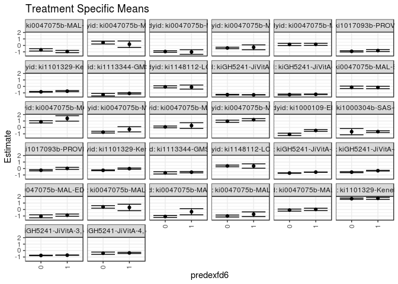

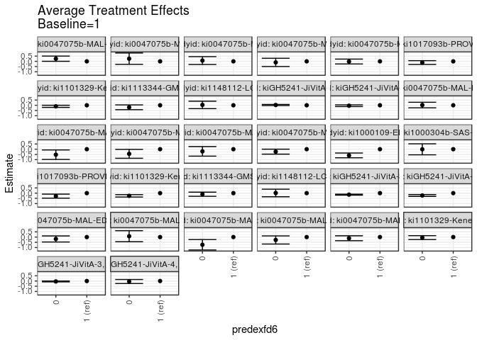

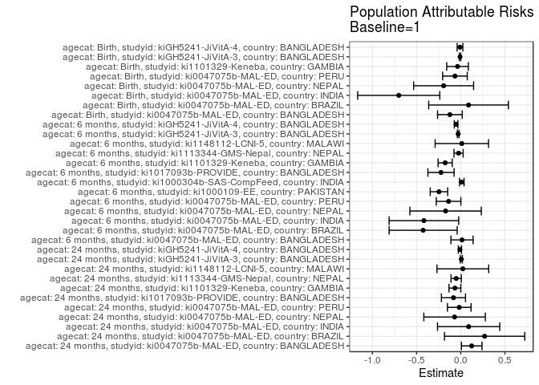

## Results Table

### Parameter: TSM

| agecat | studyid | country | intervention_level | baseline_level | estimate | ci_lower | ci_upper |
| --- | --- | --- | --- | --- | --- | --- | --- |
| Birth | ki0047075b-MAL-ED | BANGLADESH | 1 | NA | -0.8694045 | -1.0434047 | -0.6954043 |
| Birth | ki0047075b-MAL-ED | BANGLADESH | 0 | NA | -1.0496699 | -1.2809746 | -0.8183653 |
| Birth | ki0047075b-MAL-ED | BRAZIL | 1 | NA | 0.3190068 | -0.1786324 | 0.8166461 |
| Birth | ki0047075b-MAL-ED | BRAZIL | 0 | NA | 0.4025367 | 0.2051821 | 0.5998914 |
| Birth | ki0047075b-MAL-ED | INDIA | 1 | NA | -0.3413956 | -0.8194545 | 0.1366633 |
| Birth | ki0047075b-MAL-ED | INDIA | 0 | NA | -1.0779254 | -1.2265509 | -0.9292998 |
| Birth | ki0047075b-MAL-ED | NEPAL | 1 | NA | -0.7284386 | -1.0889261 | -0.3679511 |
| Birth | ki0047075b-MAL-ED | NEPAL | 0 | NA | -1.0059802 | -1.1546606 | -0.8572998 |
| Birth | ki0047075b-MAL-ED | PERU | 1 | NA | 0.0225729 | -0.1555580 | 0.2007039 |
| Birth | ki0047075b-MAL-ED | PERU | 0 | NA | -0.0894095 | -0.2443352 | 0.0655162 |
| Birth | ki1101329-Keneba | GAMBIA | 1 | NA | 1.7268373 | 1.5715792 | 1.8820954 |
| Birth | ki1101329-Keneba | GAMBIA | 0 | NA | 1.6768106 | 1.5764634 | 1.7771577 |
| Birth | kiGH5241-JiVitA-3 | BANGLADESH | 1 | NA | -0.7155659 | -0.7368781 | -0.6942537 |
| Birth | kiGH5241-JiVitA-3 | BANGLADESH | 0 | NA | -0.7562559 | -0.7958737 | -0.7166382 |
| Birth | kiGH5241-JiVitA-4 | BANGLADESH | 1 | NA | -0.3654431 | -0.4571495 | -0.2737367 |
| Birth | kiGH5241-JiVitA-4 | BANGLADESH | 0 | NA | -0.4104774 | -0.5887595 | -0.2321953 |
| 6 months | ki0047075b-MAL-ED | BANGLADESH | 1 | NA | -0.1607811 | -0.3457591 | 0.0241969 |
| 6 months | ki0047075b-MAL-ED | BANGLADESH | 0 | NA | -0.1391949 | -0.3282397 | 0.0498499 |
| 6 months | ki0047075b-MAL-ED | BRAZIL | 1 | NA | 1.3976065 | 0.9787697 | 1.8164433 |
| 6 months | ki0047075b-MAL-ED | BRAZIL | 0 | NA | 0.8705675 | 0.6919287 | 1.0492064 |
| 6 months | ki0047075b-MAL-ED | INDIA | 1 | NA | -0.2853966 | -0.6891493 | 0.1183560 |
| 6 months | ki0047075b-MAL-ED | INDIA | 0 | NA | -0.7283618 | -0.8599148 | -0.5968088 |
| 6 months | ki0047075b-MAL-ED | NEPAL | 1 | NA | 0.2884511 | -0.1523172 | 0.7292195 |
| 6 months | ki0047075b-MAL-ED | NEPAL | 0 | NA | 0.0819718 | -0.0539337 | 0.2178772 |
| 6 months | ki0047075b-MAL-ED | PERU | 1 | NA | 1.1934594 | 1.0232832 | 1.3636357 |
| 6 months | ki0047075b-MAL-ED | PERU | 0 | NA | 0.9586942 | 0.7908717 | 1.1265168 |
| 6 months | ki1000109-EE | PAKISTAN | 1 | NA | -0.4743832 | -0.6135694 | -0.3351970 |
| 6 months | ki1000109-EE | PAKISTAN | 0 | NA | -1.0685561 | -1.2477840 | -0.8893282 |
| 6 months | ki1000304b-SAS-CompFeed | INDIA | 1 | NA | -0.6465859 | -0.7848454 | -0.5083265 |
| 6 months | ki1000304b-SAS-CompFeed | INDIA | 0 | NA | -0.6556227 | -1.1386877 | -0.1725576 |
| 6 months | ki1017093b-PROVIDE | BANGLADESH | 1 | NA | 0.0153788 | -0.1514399 | 0.1821975 |
| 6 months | ki1017093b-PROVIDE | BANGLADESH | 0 | NA | -0.2716530 | -0.3687533 | -0.1745528 |
| 6 months | ki1101329-Keneba | GAMBIA | 1 | NA | -0.0234730 | -0.1206383 | 0.0736923 |
| 6 months | ki1101329-Keneba | GAMBIA | 0 | NA | -0.2808342 | -0.3437049 | -0.2179636 |
| 6 months | ki1113344-GMS-Nepal | NEPAL | 1 | NA | -0.5766021 | -0.6793127 | -0.4738915 |
| 6 months | ki1113344-GMS-Nepal | NEPAL | 0 | NA | -0.6797498 | -0.8492978 | -0.5102019 |
| 6 months | ki1148112-LCNI-5 | MALAWI | 1 | NA | 0.3806071 | 0.0426570 | 0.7185573 |
| 6 months | ki1148112-LCNI-5 | MALAWI | 0 | NA | 0.3950126 | 0.2679215 | 0.5221037 |
| 6 months | kiGH5241-JiVitA-3 | BANGLADESH | 1 | NA | -0.5638571 | -0.5853173 | -0.5423969 |
| 6 months | kiGH5241-JiVitA-3 | BANGLADESH | 0 | NA | -0.7081351 | -0.7496622 | -0.6666079 |
| 6 months | kiGH5241-JiVitA-4 | BANGLADESH | 1 | NA | -0.3442590 | -0.3908519 | -0.2976660 |
| 6 months | kiGH5241-JiVitA-4 | BANGLADESH | 0 | NA | -0.5680329 | -0.6450110 | -0.4910548 |
| 24 months | ki0047075b-MAL-ED | BANGLADESH | 1 | NA | -0.9554100 | -1.1290544 | -0.7817656 |
| 24 months | ki0047075b-MAL-ED | BANGLADESH | 0 | NA | -0.7005602 | -0.8804229 | -0.5206976 |
| 24 months | ki0047075b-MAL-ED | BRAZIL | 1 | NA | 0.1761526 | -0.3228056 | 0.6751109 |
| 24 months | ki0047075b-MAL-ED | BRAZIL | 0 | NA | 0.4319903 | 0.2097454 | 0.6542353 |
| 24 months | ki0047075b-MAL-ED | INDIA | 1 | NA | -1.0281576 | -1.3817354 | -0.6745798 |
| 24 months | ki0047075b-MAL-ED | INDIA | 0 | NA | -0.9536556 | -1.0756048 | -0.8317065 |
| 24 months | ki0047075b-MAL-ED | NEPAL | 1 | NA | -0.3003428 | -0.6770639 | 0.0763782 |
| 24 months | ki0047075b-MAL-ED | NEPAL | 0 | NA | -0.4006810 | -0.5187093 | -0.2826527 |
| 24 months | ki0047075b-MAL-ED | PERU | 1 | NA | 0.1603667 | 0.0031738 | 0.3175596 |
| 24 months | ki0047075b-MAL-ED | PERU | 0 | NA | 0.1417670 | -0.0278699 | 0.3114040 |
| 24 months | ki1017093b-PROVIDE | BANGLADESH | 1 | NA | -0.8052489 | -0.9612397 | -0.6492580 |
| 24 months | ki1017093b-PROVIDE | BANGLADESH | 0 | NA | -0.9211721 | -1.0175126 | -0.8248316 |
| 24 months | ki1101329-Keneba | GAMBIA | 1 | NA | -0.7370722 | -0.8194139 | -0.6547304 |
| 24 months | ki1101329-Keneba | GAMBIA | 0 | NA | -0.8370692 | -0.8988172 | -0.7753212 |
| 24 months | ki1113344-GMS-Nepal | NEPAL | 1 | NA | -1.0850846 | -1.1855774 | -0.9845918 |
| 24 months | ki1113344-GMS-Nepal | NEPAL | 0 | NA | -1.2782163 | -1.4795843 | -1.0768484 |
| 24 months | ki1148112-LCNI-5 | MALAWI | 1 | NA | -0.1006586 | -0.4164573 | 0.2151402 |
| 24 months | ki1148112-LCNI-5 | MALAWI | 0 | NA | -0.0656507 | -0.2281836 | 0.0968822 |
| 24 months | kiGH5241-JiVitA-3 | BANGLADESH | 1 | NA | -1.3054499 | -1.3317599 | -1.2791398 |
| 24 months | kiGH5241-JiVitA-3 | BANGLADESH | 0 | NA | -1.2807629 | -1.3285956 | -1.2329302 |
| 24 months | kiGH5241-JiVitA-4 | BANGLADESH | 1 | NA | -1.2242372 | -1.2612264 | -1.1872479 |
| 24 months | kiGH5241-JiVitA-4 | BANGLADESH | 0 | NA | -1.2664965 | -1.3411096 | -1.1918834 |

### Parameter: E(Y)

| agecat | studyid | country | intervention_level | baseline_level | estimate | ci_lower | ci_upper |
| --- | --- | --- | --- | --- | --- | --- | --- |
| Birth | ki0047075b-MAL-ED | BANGLADESH | NA | NA | -0.9925114 | -1.1346572 | -0.8503656 |
| Birth | ki0047075b-MAL-ED | BRAZIL | NA | NA | 0.4073214 | 0.2229599 | 0.5916830 |
| Birth | ki0047075b-MAL-ED | INDIA | NA | NA | -1.0435829 | -1.1865715 | -0.9005943 |
| Birth | ki0047075b-MAL-ED | NEPAL | NA | NA | -0.9226061 | -1.0630064 | -0.7822058 |
| Birth | ki0047075b-MAL-ED | PERU | NA | NA | -0.0430924 | -0.1600210 | 0.0738362 |
| Birth | ki1101329-Keneba | GAMBIA | NA | NA | 1.6904416 | 1.6057966 | 1.7750867 |
| Birth | kiGH5241-JiVitA-3 | BANGLADESH | NA | NA | -0.7234060 | -0.7433920 | -0.7034200 |
| Birth | kiGH5241-JiVitA-4 | BANGLADESH | NA | NA | -0.3738863 | -0.4580087 | -0.2897638 |
| 6 months | ki0047075b-MAL-ED | BANGLADESH | NA | NA | -0.1464929 | -0.2779745 | -0.0150113 |
| 6 months | ki0047075b-MAL-ED | BRAZIL | NA | NA | 0.9717225 | 0.8073791 | 1.1360658 |
| 6 months | ki0047075b-MAL-ED | INDIA | NA | NA | -0.7028736 | -0.8283047 | -0.5774424 |
| 6 months | ki0047075b-MAL-ED | NEPAL | NA | NA | 0.1167518 | -0.0146454 | 0.2481490 |
| 6 months | ki0047075b-MAL-ED | PERU | NA | NA | 1.0554461 | 0.9322755 | 1.1786167 |
| 6 months | ki1000109-EE | PAKISTAN | NA | NA | -0.7212766 | -0.8346857 | -0.6078675 |
| 6 months | ki1000304b-SAS-CompFeed | INDIA | NA | NA | -0.6348861 | -0.7630511 | -0.5067211 |
| 6 months | ki1017093b-PROVIDE | BANGLADESH | NA | NA | -0.2083706 | -0.2927992 | -0.1239419 |
| 6 months | ki1101329-Keneba | GAMBIA | NA | NA | -0.1997850 | -0.2531586 | -0.1464114 |
| 6 months | ki1113344-GMS-Nepal | NEPAL | NA | NA | -0.6015049 | -0.6892785 | -0.5137313 |
| 6 months | ki1148112-LCNI-5 | MALAWI | NA | NA | 0.3927574 | 0.2737700 | 0.5117448 |
| 6 months | kiGH5241-JiVitA-3 | BANGLADESH | NA | NA | -0.5931801 | -0.6126929 | -0.5736674 |
| 6 months | kiGH5241-JiVitA-4 | BANGLADESH | NA | NA | -0.3971948 | -0.4378192 | -0.3565704 |
| 24 months | ki0047075b-MAL-ED | BANGLADESH | NA | NA | -0.8315789 | -0.9546058 | -0.7085521 |
| 24 months | ki0047075b-MAL-ED | BRAZIL | NA | NA | 0.4466272 | 0.2416144 | 0.6516401 |
| 24 months | ki0047075b-MAL-ED | INDIA | NA | NA | -0.9390848 | -1.0545919 | -0.8235777 |
| 24 months | ki0047075b-MAL-ED | NEPAL | NA | NA | -0.3703084 | -0.4835704 | -0.2570464 |
| 24 months | ki0047075b-MAL-ED | PERU | NA | NA | 0.1430051 | 0.0254144 | 0.2605957 |
| 24 months | ki1017093b-PROVIDE | BANGLADESH | NA | NA | -0.8879412 | -0.9708680 | -0.8050144 |
| 24 months | ki1101329-Keneba | GAMBIA | NA | NA | -0.8032329 | -0.8532842 | -0.7531817 |
| 24 months | ki1113344-GMS-Nepal | NEPAL | NA | NA | -1.1369520 | -1.2269975 | -1.0469065 |
| 24 months | ki1148112-LCNI-5 | MALAWI | NA | NA | -0.0771196 | -0.2204715 | 0.0662323 |
| 24 months | kiGH5241-JiVitA-3 | BANGLADESH | NA | NA | -1.2991319 | -1.3225545 | -1.2757094 |
| 24 months | kiGH5241-JiVitA-4 | BANGLADESH | NA | NA | -1.2337581 | -1.2679680 | -1.1995482 |

### Parameter: ATE

| agecat | studyid | country | intervention_level | baseline_level | estimate | ci_lower | ci_upper |
| --- | --- | --- | --- | --- | --- | --- | --- |
| Birth | ki0047075b-MAL-ED | BANGLADESH | 1 | 1 | 0.0000000 | 0.0000000 | 0.0000000 |
| Birth | ki0047075b-MAL-ED | BANGLADESH | 0 | 1 | -0.1802654 | -0.4716777 | 0.1111468 |
| Birth | ki0047075b-MAL-ED | BRAZIL | 1 | 1 | 0.0000000 | 0.0000000 | 0.0000000 |
| Birth | ki0047075b-MAL-ED | BRAZIL | 0 | 1 | 0.0835299 | -0.4463358 | 0.6133956 |
| Birth | ki0047075b-MAL-ED | INDIA | 1 | 1 | 0.0000000 | 0.0000000 | 0.0000000 |
| Birth | ki0047075b-MAL-ED | INDIA | 0 | 1 | -0.7365297 | -1.2379959 | -0.2350635 |
| Birth | ki0047075b-MAL-ED | NEPAL | 1 | 1 | 0.0000000 | 0.0000000 | 0.0000000 |
| Birth | ki0047075b-MAL-ED | NEPAL | 0 | 1 | -0.2775416 | -0.6664775 | 0.1113943 |
| Birth | ki0047075b-MAL-ED | PERU | 1 | 1 | 0.0000000 | 0.0000000 | 0.0000000 |
| Birth | ki0047075b-MAL-ED | PERU | 0 | 1 | -0.1119824 | -0.3483948 | 0.1244300 |
| Birth | ki1101329-Keneba | GAMBIA | 1 | 1 | 0.0000000 | 0.0000000 | 0.0000000 |
| Birth | ki1101329-Keneba | GAMBIA | 0 | 1 | -0.0500267 | -0.2350256 | 0.1349722 |
| Birth | kiGH5241-JiVitA-3 | BANGLADESH | 1 | 1 | 0.0000000 | 0.0000000 | 0.0000000 |
| Birth | kiGH5241-JiVitA-3 | BANGLADESH | 0 | 1 | -0.0406901 | -0.0817791 | 0.0003990 |
| Birth | kiGH5241-JiVitA-4 | BANGLADESH | 1 | 1 | 0.0000000 | 0.0000000 | 0.0000000 |
| Birth | kiGH5241-JiVitA-4 | BANGLADESH | 0 | 1 | -0.0450343 | -0.2376667 | 0.1475981 |
| 6 months | ki0047075b-MAL-ED | BANGLADESH | 1 | 1 | 0.0000000 | 0.0000000 | 0.0000000 |
| 6 months | ki0047075b-MAL-ED | BANGLADESH | 0 | 1 | 0.0215862 | -0.2445103 | 0.2876827 |
| 6 months | ki0047075b-MAL-ED | BRAZIL | 1 | 1 | 0.0000000 | 0.0000000 | 0.0000000 |
| 6 months | ki0047075b-MAL-ED | BRAZIL | 0 | 1 | -0.5270390 | -0.9824026 | -0.0716753 |
| 6 months | ki0047075b-MAL-ED | INDIA | 1 | 1 | 0.0000000 | 0.0000000 | 0.0000000 |
| 6 months | ki0047075b-MAL-ED | INDIA | 0 | 1 | -0.4429651 | -0.8675258 | -0.0184045 |
| 6 months | ki0047075b-MAL-ED | NEPAL | 1 | 1 | 0.0000000 | 0.0000000 | 0.0000000 |
| 6 months | ki0047075b-MAL-ED | NEPAL | 0 | 1 | -0.2064794 | -0.6644068 | 0.2514481 |
| 6 months | ki0047075b-MAL-ED | PERU | 1 | 1 | 0.0000000 | 0.0000000 | 0.0000000 |
| 6 months | ki0047075b-MAL-ED | PERU | 0 | 1 | -0.2347652 | -0.4723359 | 0.0028055 |
| 6 months | ki1000109-EE | PAKISTAN | 1 | 1 | 0.0000000 | 0.0000000 | 0.0000000 |
| 6 months | ki1000109-EE | PAKISTAN | 0 | 1 | -0.5941729 | -0.8212901 | -0.3670557 |
| 6 months | ki1000304b-SAS-CompFeed | INDIA | 1 | 1 | 0.0000000 | 0.0000000 | 0.0000000 |
| 6 months | ki1000304b-SAS-CompFeed | INDIA | 0 | 1 | -0.0090367 | -0.5362411 | 0.5181676 |
| 6 months | ki1017093b-PROVIDE | BANGLADESH | 1 | 1 | 0.0000000 | 0.0000000 | 0.0000000 |
| 6 months | ki1017093b-PROVIDE | BANGLADESH | 0 | 1 | -0.2870319 | -0.4800982 | -0.0939656 |
| 6 months | ki1101329-Keneba | GAMBIA | 1 | 1 | 0.0000000 | 0.0000000 | 0.0000000 |
| 6 months | ki1101329-Keneba | GAMBIA | 0 | 1 | -0.2573612 | -0.3720059 | -0.1427166 |
| 6 months | ki1113344-GMS-Nepal | NEPAL | 1 | 1 | 0.0000000 | 0.0000000 | 0.0000000 |
| 6 months | ki1113344-GMS-Nepal | NEPAL | 0 | 1 | -0.1031477 | -0.3015344 | 0.0952389 |
| 6 months | ki1148112-LCNI-5 | MALAWI | 1 | 1 | 0.0000000 | 0.0000000 | 0.0000000 |
| 6 months | ki1148112-LCNI-5 | MALAWI | 0 | 1 | 0.0144055 | -0.3479335 | 0.3767445 |
| 6 months | kiGH5241-JiVitA-3 | BANGLADESH | 1 | 1 | 0.0000000 | 0.0000000 | 0.0000000 |
| 6 months | kiGH5241-JiVitA-3 | BANGLADESH | 0 | 1 | -0.1442780 | -0.1893429 | -0.0992130 |
| 6 months | kiGH5241-JiVitA-4 | BANGLADESH | 1 | 1 | 0.0000000 | 0.0000000 | 0.0000000 |
| 6 months | kiGH5241-JiVitA-4 | BANGLADESH | 0 | 1 | -0.2237739 | -0.3118790 | -0.1356688 |
| 24 months | ki0047075b-MAL-ED | BANGLADESH | 1 | 1 | 0.0000000 | 0.0000000 | 0.0000000 |
| 24 months | ki0047075b-MAL-ED | BANGLADESH | 0 | 1 | 0.2548498 | 0.0041791 | 0.5055205 |
| 24 months | ki0047075b-MAL-ED | BRAZIL | 1 | 1 | 0.0000000 | 0.0000000 | 0.0000000 |
| 24 months | ki0047075b-MAL-ED | BRAZIL | 0 | 1 | 0.2558377 | -0.2882103 | 0.7998858 |
| 24 months | ki0047075b-MAL-ED | INDIA | 1 | 1 | 0.0000000 | 0.0000000 | 0.0000000 |
| 24 months | ki0047075b-MAL-ED | INDIA | 0 | 1 | 0.0745019 | -0.3020247 | 0.4510286 |
| 24 months | ki0047075b-MAL-ED | NEPAL | 1 | 1 | 0.0000000 | 0.0000000 | 0.0000000 |
| 24 months | ki0047075b-MAL-ED | NEPAL | 0 | 1 | -0.1003381 | -0.4954595 | 0.2947832 |
| 24 months | ki0047075b-MAL-ED | PERU | 1 | 1 | 0.0000000 | 0.0000000 | 0.0000000 |
| 24 months | ki0047075b-MAL-ED | PERU | 0 | 1 | -0.0185997 | -0.2505091 | 0.2133098 |
| 24 months | ki1017093b-PROVIDE | BANGLADESH | 1 | 1 | 0.0000000 | 0.0000000 | 0.0000000 |
| 24 months | ki1017093b-PROVIDE | BANGLADESH | 0 | 1 | -0.1159232 | -0.2975370 | 0.0656905 |
| 24 months | ki1101329-Keneba | GAMBIA | 1 | 1 | 0.0000000 | 0.0000000 | 0.0000000 |
| 24 months | ki1101329-Keneba | GAMBIA | 0 | 1 | -0.0999971 | -0.2015774 | 0.0015833 |
| 24 months | ki1113344-GMS-Nepal | NEPAL | 1 | 1 | 0.0000000 | 0.0000000 | 0.0000000 |
| 24 months | ki1113344-GMS-Nepal | NEPAL | 0 | 1 | -0.1931318 | -0.4204487 | 0.0341852 |
| 24 months | ki1148112-LCNI-5 | MALAWI | 1 | 1 | 0.0000000 | 0.0000000 | 0.0000000 |
| 24 months | ki1148112-LCNI-5 | MALAWI | 0 | 1 | 0.0350079 | -0.3207724 | 0.3907881 |
| 24 months | kiGH5241-JiVitA-3 | BANGLADESH | 1 | 1 | 0.0000000 | 0.0000000 | 0.0000000 |
| 24 months | kiGH5241-JiVitA-3 | BANGLADESH | 0 | 1 | 0.0246870 | -0.0290365 | 0.0784106 |
| 24 months | kiGH5241-JiVitA-4 | BANGLADESH | 1 | 1 | 0.0000000 | 0.0000000 | 0.0000000 |
| 24 months | kiGH5241-JiVitA-4 | BANGLADESH | 0 | 1 | -0.0422593 | -0.1234254 | 0.0389068 |

### Parameter: PAR

| agecat | studyid | country | intervention_level | baseline_level | estimate | ci_lower | ci_upper |
| --- | --- | --- | --- | --- | --- | --- | --- |
| Birth | ki0047075b-MAL-ED | BANGLADESH | 1 | NA | -0.1231069 | -0.2629687 | 0.0167549 |
| Birth | ki0047075b-MAL-ED | BRAZIL | 1 | NA | 0.0883146 | -0.3628719 | 0.5395010 |
| Birth | ki0047075b-MAL-ED | INDIA | 1 | NA | -0.7021873 | -1.1672118 | -0.2371627 |
| Birth | ki0047075b-MAL-ED | NEPAL | 1 | NA | -0.1941674 | -0.5337634 | 0.1454285 |
| Birth | ki0047075b-MAL-ED | PERU | 1 | NA | -0.0656653 | -0.2050395 | 0.0737089 |
| Birth | ki1101329-Keneba | GAMBIA | 1 | NA | -0.0363957 | -0.1590751 | 0.0862837 |
| Birth | kiGH5241-JiVitA-3 | BANGLADESH | 1 | NA | -0.0078401 | -0.0160127 | 0.0003325 |
| Birth | kiGH5241-JiVitA-4 | BANGLADESH | 1 | NA | -0.0084431 | -0.0407765 | 0.0238903 |
| 6 months | ki0047075b-MAL-ED | BANGLADESH | 1 | NA | 0.0142882 | -0.1113160 | 0.1398925 |
| 6 months | ki0047075b-MAL-ED | BRAZIL | 1 | NA | -0.4258840 | -0.8112886 | -0.0404795 |
| 6 months | ki0047075b-MAL-ED | INDIA | 1 | NA | -0.4174769 | -0.8113629 | -0.0235909 |
| 6 months | ki0047075b-MAL-ED | NEPAL | 1 | NA | -0.1716994 | -0.5760445 | 0.2326457 |
| 6 months | ki0047075b-MAL-ED | PERU | 1 | NA | -0.1380133 | -0.2775454 | 0.0015188 |
| 6 months | ki1000109-EE | PAKISTAN | 1 | NA | -0.2468934 | -0.3456221 | -0.1481647 |
| 6 months | ki1000304b-SAS-CompFeed | INDIA | 1 | NA | 0.0116999 | -0.0141795 | 0.0375792 |
| 6 months | ki1017093b-PROVIDE | BANGLADESH | 1 | NA | -0.2237494 | -0.3721020 | -0.0753968 |
| 6 months | ki1101329-Keneba | GAMBIA | 1 | NA | -0.1763120 | -0.2562191 | -0.0964049 |
| 6 months | ki1113344-GMS-Nepal | NEPAL | 1 | NA | -0.0249028 | -0.0765241 | 0.0267186 |
| 6 months | ki1148112-LCNI-5 | MALAWI | 1 | NA | 0.0121502 | -0.2902258 | 0.3145263 |
| 6 months | kiGH5241-JiVitA-3 | BANGLADESH | 1 | NA | -0.0293230 | -0.0388403 | -0.0198058 |
| 6 months | kiGH5241-JiVitA-4 | BANGLADESH | 1 | NA | -0.0529359 | -0.0731594 | -0.0327123 |
| 24 months | ki0047075b-MAL-ED | BANGLADESH | 1 | NA | 0.1238311 | 0.0073455 | 0.2403166 |
| 24 months | ki0047075b-MAL-ED | BRAZIL | 1 | NA | 0.2704746 | -0.1841682 | 0.7251174 |
| 24 months | ki0047075b-MAL-ED | INDIA | 1 | NA | 0.0890727 | -0.2634668 | 0.4416123 |
| 24 months | ki0047075b-MAL-ED | NEPAL | 1 | NA | -0.0699655 | -0.4182248 | 0.2782937 |
| 24 months | ki0047075b-MAL-ED | PERU | 1 | NA | -0.0173617 | -0.1510929 | 0.1163696 |
| 24 months | ki1017093b-PROVIDE | BANGLADESH | 1 | NA | -0.0826923 | -0.2190428 | 0.0536581 |
| 24 months | ki1101329-Keneba | GAMBIA | 1 | NA | -0.0661608 | -0.1332586 | 0.0009371 |
| 24 months | ki1113344-GMS-Nepal | NEPAL | 1 | NA | -0.0518674 | -0.1101658 | 0.0064309 |
| 24 months | ki1148112-LCNI-5 | MALAWI | 1 | NA | 0.0235390 | -0.2692914 | 0.3163694 |
| 24 months | kiGH5241-JiVitA-3 | BANGLADESH | 1 | NA | 0.0063180 | -0.0053562 | 0.0179921 |
| 24 months | kiGH5241-JiVitA-4 | BANGLADESH | 1 | NA | -0.0095209 | -0.0272574 | 0.0082156 |